# AMAP: Assisted Microbial Annotation Pipeline Report

## Annotation Quality Metrics

Per-sample assembly and annotation quality: genome size, GC%, coding density, hypothetical %, and functional annotation rate.

### Overview Table

| sample | genome_size | n_contigs | n50 | gc_pct | total_cds | pseudogene_count | hypothetical_pct | mean_gene_length | median_gene_length | coding_density_pct | eggnog_annotation_pct |
| --- | --- | --- | --- | --- | --- | --- | --- | --- | --- | --- | --- |
| L1_G10000 | 4357280 | 1 | 4357280 | 65.52 | 4052 | 6 | 11.4 | 1006 | 832 | 90.7 | 92.6 |
| L1_G10007 | 4451050 | 1 | 4451050 | 65.62 | 4048 | 19 | 12.3 | 1011 | 852 | 91.3 | 89.1 |
| L1_G10014 | 4412939 | 1 | 4412939 | 65.47 | 4071 | 8 | 10.7 | 986 | 842 | 91 | 89.3 |
| L2_G10100 | 4394057 | 1 | 4394057 | 65.51 | 4000 | 12 | 10.6 | 982 | 831 | 91.6 | 90.4 |
| L2_G10107 | 4366899 | 1 | 4366899 | 65.79 | 3982 | 9 | 11.7 | 1006 | 851 | 91.6 | 90.8 |
| L2_G10114 | 4434709 | 1 | 4434709 | 65.59 | 4063 | 15 | 10.5 | 984 | 827 | 91.8 | 92.6 |
| L3_G10200 | 4455905 | 1 | 4455905 | 65.8 | 3954 | 6 | 10.8 | 996 | 837 | 90.9 | 91.8 |
| L3_G10207 | 4399013 | 1 | 4399013 | 65.6 | 4100 | 19 | 11.8 | 981 | 866 | 91.1 | 88.8 |
| L3_G10214 | 4415508 | 1 | 4415508 | 65.73 | 4052 | 17 | 11.5 | 988 | 864 | 91.8 | 88.6 |
| L4_G10300 | 4356949 | 1 | 4356949 | 65.63 | 4012 | 11 | 10.9 | 981 | 865 | 91.6 | 91 |

[output cut: 2 more lines]

### Coding Density

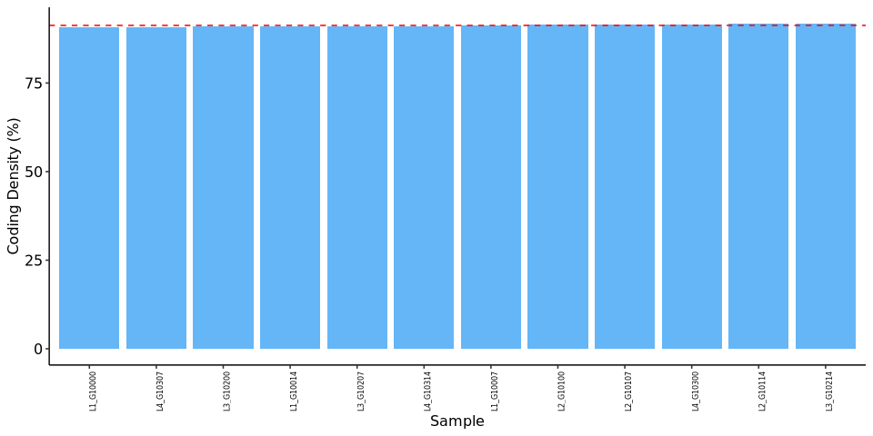

### Hypothetical %

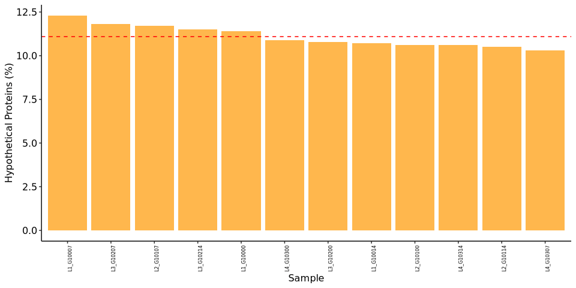

### Genome Size Distribution

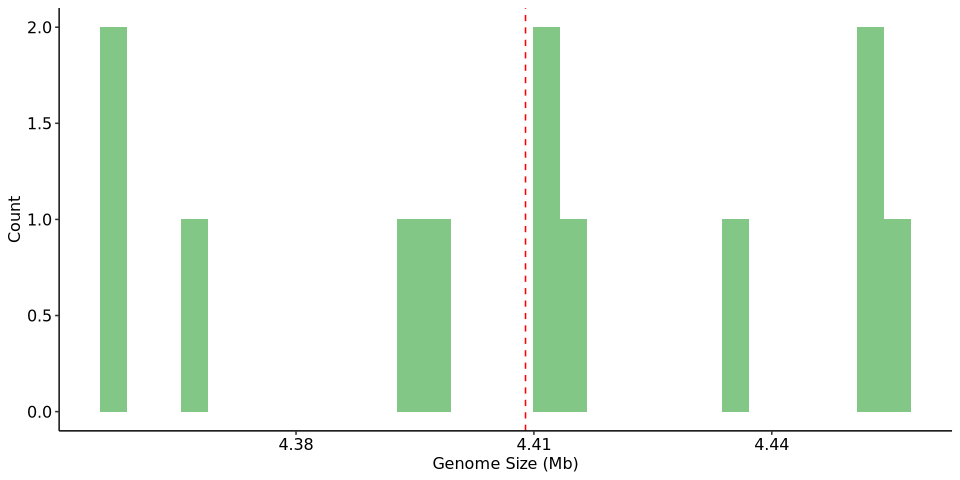